# Useful one-function `R` packages, big data solutions, and a message from Yoda

Eduardo García-Portugués

2018-05-10

**Abstract**

You can download the script with the `R` code alone [here](https://raw.githubusercontent.com/CodingClubUC3M/codingclubuc3m.github.io/master/scripts/misc.R) (right click and “Save as…”).

**Required packages**

We will need the following packages:

```r
install.packages(c("viridis", "microbenchmark", "multcomp", "manipulate",
                   "ffbase", "biglm", "leaps", "txtplot", "NostalgiR",
                   "cowsay","vembedr"),
                 dependencies = TRUE)
```

# 1 Some simple and useful `R` packages

## 1.1 Color palettes with `viridis`

Built-in color palettes in base `R` are somehow limited. We have `rainbow`, `topo.colors`, `terrain.colors`, `heat.colors`, and `cm.colors`. We also have flexibility to create our own palettes, e.g. by using `colorRamp`. These palettes look like:

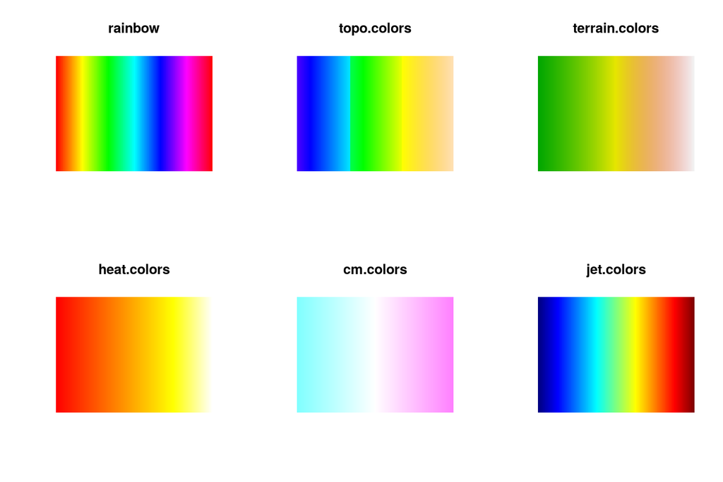

```r
# MATLAB's color palette
jet.colors <- colorRampPalette(c("#00007F", "blue", "#007FFF", "cyan",
                                 "#7FFF7F", "yellow", "#FF7F00", "red",
                                 "#7F0000"))
# Plot for palettes
testPalette <- function(col, n = 200, ...) {
  image(1:n, 1, as.matrix(1:n), col = get(col)(n = n, ...),
        main = col, xlab = "", ylab = "", axes = FALSE)
}

# Color palettes comparison
par(mfrow = c(2, 3))
res <- sapply(c("rainbow", "topo.colors", "terrain.colors",
                "heat.colors", "cm.colors", "jet.colors"), testPalette)
```

Notice that some palettes clearly show **non-uniformity in the color gradient**. This potentially leads to an **interpretation bias** when inspecting heatmaps colored by these scales: some features are (unfairly) weakened and others are (unfairly) strengthen. This distortion on the representation of the data can be quite misleading.

In addition to these problems, some problematic points that are not usually thought when choosing a color scale are:

- How does your pretty color image look like when you print it in **black-and-white**?
- How do **colorblind** people read the images?

The package [`viridisLite`](https://cran.r-project.org/web/packages/viridisLite/index.html) (a port from `Python`’s [`Matplotlib`](http://matplotlib.org/)) comes to solve these three issues. It provides the *viridis* color palette, which uses notions from color theory to be **as much uniform as possible**, **black-and-white-ready**, and **colorblind-friendly**. From `viridisLite`’s help:

> This color map is designed in such a way that it will analytically be perfectly perceptually-uniform, both in regular form and also when converted to black-and-white. It is also designed to be perceived by readers with the most common form of color blindness.

In the extended [`viridis`](https://cran.r-project.org/web/packages/viridis/index.html) package there are color palettes functions for `ggplot2` fans: `scale_color_viridis` and `scale_fill_viridis`. Some examples of their use:

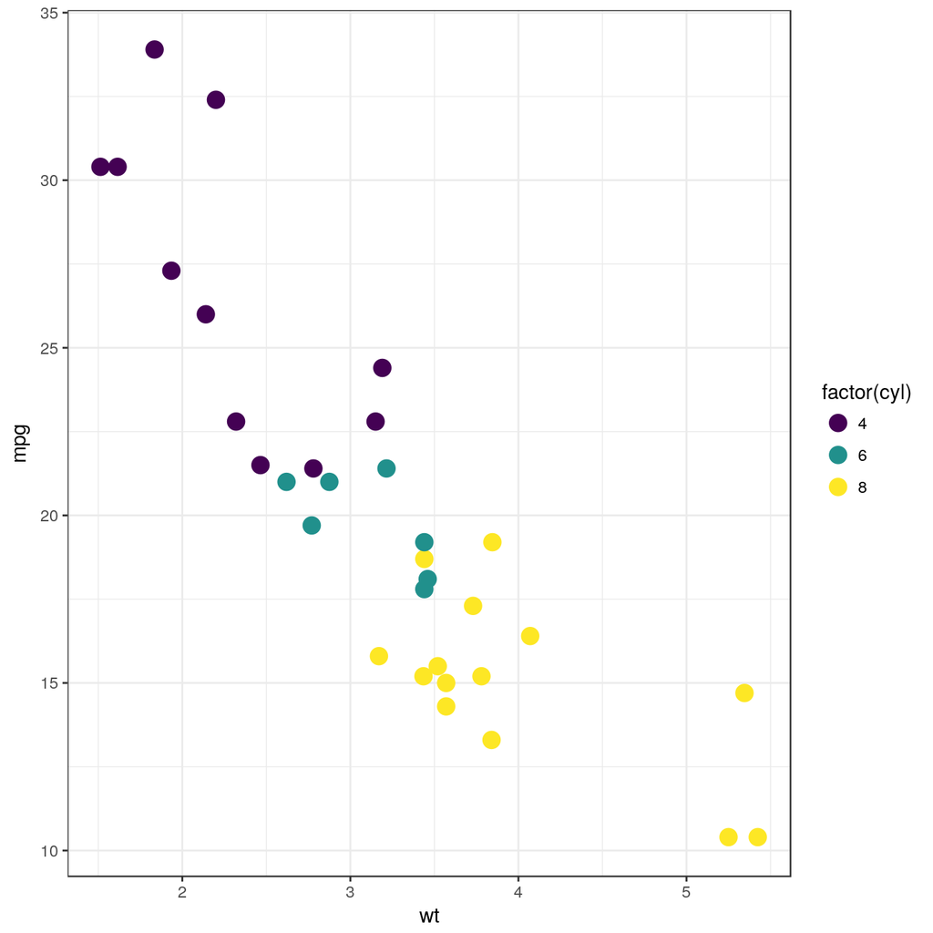

```r
library(viridis)
library(ggplot2)

# Using scale_color_viridis
ggplot(mtcars, aes(wt, mpg)) +
  geom_point(size = 4, aes(color = factor(cyl))) +
  scale_color_viridis(discrete = TRUE) +
  theme_bw()
```

# 2 Markdown cheatsheet

# 3 Heading 1

```
Markup :  # Heading 1 #

-OR-

Markup :  ============= (below H1 text)
```

## 3.1 Heading 2

```
Markup :  ## Heading 2 ##

-OR-

Markup: --------------- (below H2 text)
```

### 3.1.1 Heading 3

```
Markup :  ### Heading 3 ###
```

#### 3.1.1.1 Heading 4

```
Markup :  #### Heading 4 ####
```

Common text

```
Markup :  Common text
```

*Emphasized text*

```
Markup :  _Emphasized text_ or *Emphasized text*
```

Strikethrough text

```
Markup :  ~~Strikethrough text~~
```

**Strong text**

```
Markup :  __Strong text__ or **Strong text**
```

*Strong emphasized text*

```
Markup :  ___Strong emphasized text___ or ***Strong emphasized text***
```

[Named Link](http://www.google.fr/) and http://www.google.fr/ or http://example.com/

```
Markup :  [Named Link](http://www.google.fr/) and http://www.google.fr/ or <http://example.com/>
```

Table, like this one :

| First Header | Second Header |
| --- | --- |
| Content Cell | Content Cell |
| Content Cell | Content Cell |

```
First Header  | Second Header
------------- | -------------
Content Cell  | Content Cell
Content Cell  | Content Cell
```

`code()`

```
Markup :  `code()`
```

```javascript
    var specificLanguage_code =
    {
        "data": {
            "lookedUpPlatform": 1,
            "query": "Kasabian+Test+Transmission",
            "lookedUpItem": {
                "name": "Test Transmission",
                "artist": "Kasabian",
                "album": "Kasabian",
                "picture": null,
                "link": "http://open.spotify.com/track/5jhJur5n4fasblLSCOcrTp"
            }
        }
    }
```

````
Markup : ```javascript
         ```
````

- Bullet list
  - Nested bullet
    - Sub-nested bullet etc
- Bullet list item 2

```
 Markup : * Bullet list
              * Nested bullet
                  * Sub-nested bullet etc
          * Bullet list item 2
```

1. A numbered list
   1. A nested numbered list
   2. Which is numbered
2. Which is numbered

```
 Markup : 1. A numbered list
              1. A nested numbered list
              2. Which is numbered
          2. Which is numbered
```

- [ ] An uncompleted task
- [x] A completed task

```
 Markup : - [ ] An uncompleted task
          - [x] A completed task
```

> Blockquote > Nested blockquote

```
Markup :  > Blockquote
          >> Nested Blockquote
```

*Horizontal line :* - - - -

```
Markup :  - - - -
```

*Image with alt :*

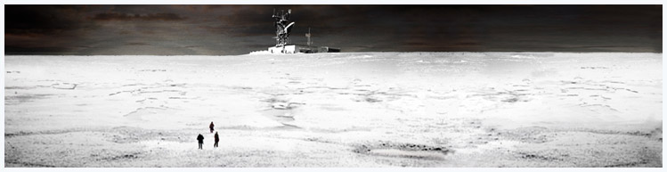

picture alt

```
Markup : ![picture alt](http://www.brightlightpictures.com/assets/images/portfolio/thethaw_header.jpg "Title is optional")
```

Foldable text:

**Title 1**

Content 1 Content 1 Content 1 Content 1 Content 1

**Title 2**

Content 2 Content 2 Content 2 Content 2 Content 2

```
Markup : <details>
           <summary>Title 1</summary>
           <p>Content 1 Content 1 Content 1 Content 1 Content 1</p>
         </details>
```

Hotkey:

`⌘F`

`⇧⌘F`

```
Markup : <kbd>⌘F</kbd>
```

Hotkey list:

| Key | Symbol |
| --- | --- |
| Option | ⌥ |
| Control | ⌃ |
| Command | ⌘ |
| Shift | ⇧ |
| Caps Lock | ⇪ |
| Tab | ⇥ |
| Esc | ⎋ |
| Power | ⌽ |
| Return | ↩ |
| Delete | ⌫ |
| Up | ↑ |
| Down | ↓ |
| Left | ← |
| Right | → |

Emoji:

:exclamation: Use emoji icons to enhance text. :+1: Look up emoji codes at [emoji-cheat-sheet.com](http://emoji-cheat-sheet.com/)

```
Markup : Code appears between colons :EMOJICODE:
```